# BDA Second Homework Assignment

2024-05-25

# Exercise 8.5

*Suppose we produce ten bootstrapped samples from a data set containing red and green classes. We then apply a classification tree to each bootstrapped sample and, for a specific value of X, produce 10 estimates of P(Class is Red|X):*

*0.1, 0.15, 0.2, 0.2, 0.55, 0.6, 0.6, 0.65, 0.7, and 0.75.*

*There are two common ways to combine these results together into a single class prediction. One is the majority vote approach discussed in this chapter. The second approach is to classify based on the average probability. In this example, what is the final classification under each of these two approaches?*

In this exercise I cover the two approaches to combine the given probabilities for “Red” and for “Green” into a single class prediction.

**Approach 1: The Majority Vote**

In the majority vote approach, each of the ten bootstrapped samples provides a vote for the class (either Red or Green). If the probability P(Class is Red|X) is greater than 0.5, it votes for Red, otherwise, it votes for Green. Looking at the probabilities provided, we can assign each of them to one of these colors:

- 0.1 → Green
- 0.15 → Green
- 0.2 → Green
- 0.2 → Green
- 0.55 → Red
- 0.6 → Red
- 0.6 → Red
- 0.65 → Red
- 0.7 → Red
- 0.75 → Red

In this case, since Red has the majority of votes, the final classification using the majority approach is Red.

**Approach 2: Average Probability**

In the average probability approach, I calculate the average of the ten probability estimates and classify based on whether the average probability is greater than 0.5 (Red) or not (Green).

Calculating the average probability:

Average Probability = (0.1+0.15+0.2+0.2+0.55+0.6+0.6+0.65+0.7+0.75)/10 = 4.5/10 = 0.45

Since the average probability is 0.45, which is less than 0.5, the final classification using the average probability approach is Green.

# Exercise 9.6

*At the end of Section 9.6.1, it is claimed that in the case of data that is just barely linearly separable, a support vector classifer with a small value of cost that misclassifes a couple of training observations may perform better on test data than one with a huge value of cost that does not misclassify any training observations. You will now investigate this claim.*

# Part a

*Generate two-class data with p = 2 in such a way that the classes are just barely linearly separable.*

```r
set.seed(248)
```

Generate barely linearly separable data using uniform distribution

```r
x1 <- runif(248, -5, 5)
x2 <- runif(248, -5, 5)
y1 <- runif(248, -5, 5)
y2 <- runif(248, -5, 5)
```

Combine the data

```r
x <- c(x1, x2)
y <- c(y1, y2)
```

Adjust labels based on the condition involving x and y

```r
labels <- numeric(496)
for (i in 1:496) {
  if (x[i] - y[i] < 0) {
    labels[i] <- 1
  } else {
    labels[i] <- -1
  }
}
labels <- factor(labels) # Convert to factor
```

Create a data frame

```r
data <- data.frame(x = x, y = y, class = labels)
```

Plot the data

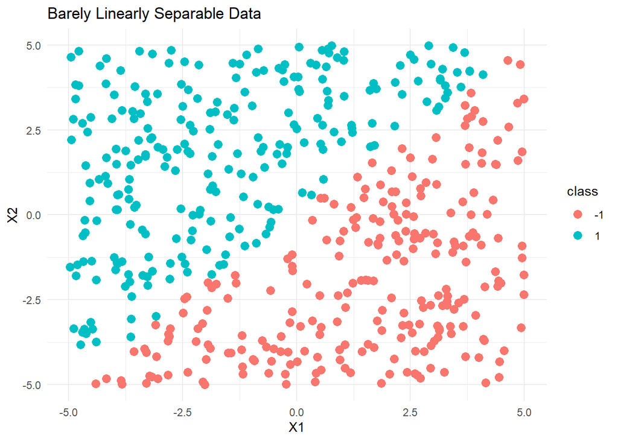

```r
library(ggplot2)
ggplot(data, aes(x = x, y = y, color = class)) +
  geom_point(size = 3) +
  labs(title = "Barely Linearly Separable Data", x = "X1", y = "X2") +
  theme_minimal()
```

# Part b

*Compute the cross-validation error rates for support vector classifers with a range of cost values. How many training observations are misclassifed for each value of cost considered, and how does this relate to the cross-validation errors obtained?*

Define a range of cost values

```r
cost_values <- c(0.001, 0.01, 0.1, 1, 5, 10, 100, 1000)
```

Perform cross-validation

```r
library(e1071)
tune_out <- tune(svm, class ~ ., data = data, kernel = "linear",
                 ranges = list(cost = cost_values))
```

Extract the best model and cross-validation error rates

```r
cv_errors <- tune_out$performances$error
```

Plot the cross-validation error rates

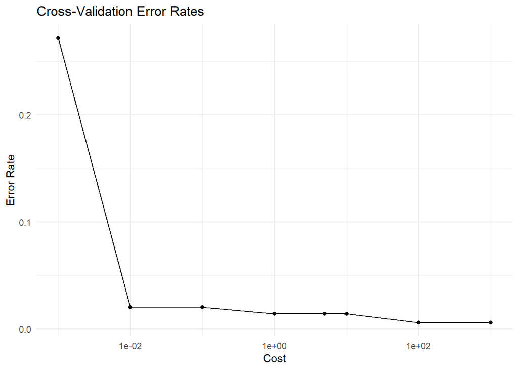

```r
cv_data <- data.frame(cost = tune_out$performances$cost, error = cv_errors)
ggplot(cv_data, aes(x = cost, y = error)) +
  geom_line() +
  geom_point() +
  scale_x_log10() +
  labs(title = "Cross-Validation Error Rates", x = "Cost", y = "Error Rate") +
  theme_minimal()
```

The plot displays the cross-validation error rates for different values of the cost parameter in an SVM model. The x-axis represents the cost values on a logarithmic scale, and the y-axis represents the error rate. We can see that the error falls as cost increases.

Extract the number of training observations

```r
num_obs <- nrow(data)
```

Compute the number of misclassified observations for each cost value

```r
misclassifications <- cv_errors * num_obs
```

Combine cost, error rate, and misclassifications into a data frame

```r
cv_data <- data.frame(cost = tune_out$performances$cost,
                      error_rate = cv_errors,
                      misclassifications = misclassifications)
```

Print the data frame to see the results

```r
print(cv_data)
```

```
##    cost error_rate misclassifications
## 1 1e-03 0.27191837         134.871510
## 2 1e-02 0.02008163           9.960490
## 3 1e-01 0.02012245           9.980735
## 4 1e+00 0.01404082           6.964245
## 5 5e+00 0.01400000           6.944000
## 6 1e+01 0.01400000           6.944000
## 7 1e+02 0.00600000           2.976000
## 8 1e+03 0.00600000           2.976000
```

- As the cost value increases from 0.001 to 1000, the cross-validation error rate initially drops significantly and then stabilizes.
- The error rates decrease, indicating better model performance with higher cost values up to a point.

Plot the cross-validation error rates with misclassification counts

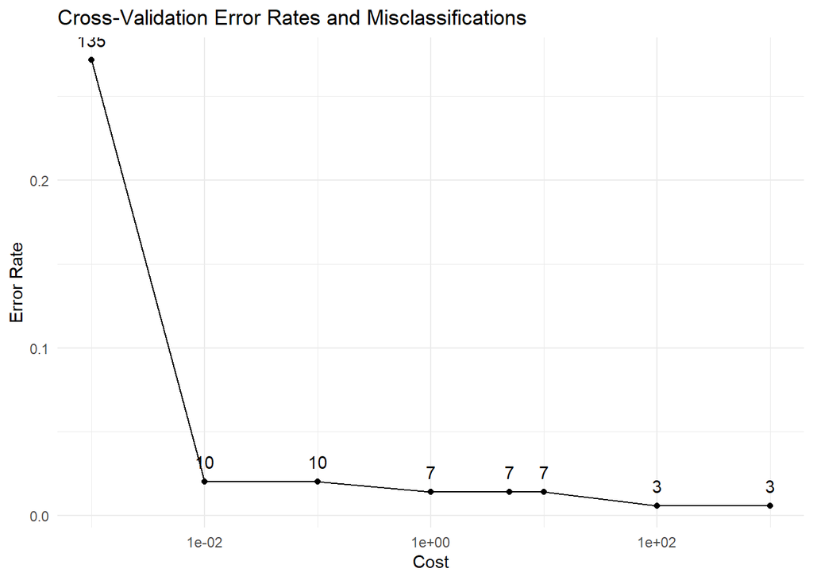

```r
ggplot(cv_data, aes(x = cost, y = error_rate)) +
  geom_line() +
  geom_point() +
  scale_x_log10() +
  labs(title = "Cross-Validation Error Rates and Misclassifications",
       x = "Cost", y = "Error Rate") +
  theme_minimal() +
  geom_text(aes(label = round(misclassifications)), vjust = -1)
```

This graph represents the cross-validation error rates and the corresponding number of misclassifications for different values of the cost parameter in an SVM model. *It is basically the same as the previous plot, but I added counts of misclassification for easier interpretations.*

There is a significant drop in the error rate when moving from a very low cost value (0.001) to a slightly higher cost value (0.01). This suggests that the model becomes more accurate as the penalty for misclassification increases. However, as the cost increases beyong 0.01, there is barely any decrease in the error, indicating that possibly there is no need to increase the cost to gain minimal increase in proecision.

# Part c

*Generate an appropriate test data set, and compute the test errors corresponding to each of the values of cost considered. Which value of cost leads to the fewest test errors, and how does this compare to the values of cost that yield the fewest training errors and the fewest cross-validation errors?*

Set a different seed from part b

```r
set.seed(2024)
```

Generate test data using uniform distribution

```r
x1_test <- runif(248, -5, 5)
x2_test <- runif(248, -5, 5)
```

The code below fills a vector with test labels. For each iteration *i*, check whether the value of *x1_test[i]* is less than the value of *x2_test[i]*. If yes, assign a label 1, otherwise assign -1.

```r
labels_test <- numeric(248) # Initialize vector for test labels
for (i in 1:248) {
  if (x1_test[i] - x2_test[i] < 0) {
    labels_test[i] <- 1
  } else {
    labels_test[i] <- -1
  }
}
labels_test <- factor(labels_test) # Convert to factor
```

Create a test data frame with adjusted labels

```r
test_data <- data.frame(x = x1_test, y = x2_test, class = labels_test)
```

Create a vector of 0’s to store test errors

```r
test_errors <- numeric(length(cost_values))
```

Evaluate the model performance for each cost value

```r
for (i in 1:length(cost_values)) {
  svm_model <- svm(class ~ ., data = data, kernel = "linear", cost = cost_values[i])
  predictions <- predict(svm_model, newdata = test_data)
  test_errors[i] <- mean(predictions != test_data$class)
}
```

Combine cost and test error rates into a data frame

```r
test_data_frame <- data.frame(cost = cost_values, test_error_rate = test_errors)
```

Print the data frame to see the results

```r
print(test_data_frame)
```

```
##    cost test_error_rate
## 1 1e-03     0.116935484
## 2 1e-02     0.020161290
## 3 1e-01     0.016129032
## 4 1e+00     0.016129032
## 5 5e+00     0.012096774
## 6 1e+01     0.008064516
## 7 1e+02     0.004032258
## 8 1e+03     0.000000000
```

- As the cost increases, the test error rate consistently decreases.
- For higher cost values (100 and 1000), the test error rates are very low, with the lowest error rate of 0.0000 at a cost of 1000.
- This indicates that the model performs better on test data with higher cost values, leading to a more accurate model.
- On the other hand, after the first decrease in error rate that yields much higher accuracy, we can see that further increases in costs give only marginally smaller error rates.

Plot the test error rates

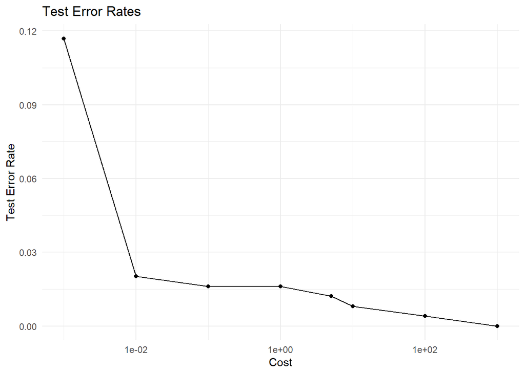

```r
library(ggplot2)
ggplot(test_data_frame, aes(x = cost, y = test_error_rate)) +
  geom_line() +
  geom_point() +
  scale_x_log10() +
  labs(title = "Test Error Rates", x = "Cost", y = "Test Error Rate") +
  theme_minimal()
```

The plot represents the costs and the error rates assigned to each of them. This plot visualizes the results of the table above.

Compare test error rates with cross-validation error rates

```r
comparison_data <- data.frame(cost = cost_values,
                              cv_error_rate = cv_errors[match(cost_values, cost_values)],
                              test_error_rate = test_errors)

print(comparison_data)
```

```
##    cost cv_error_rate test_error_rate
## 1 1e-03    0.27191837     0.116935484
## 2 1e-02    0.02008163     0.020161290
## 3 1e-01    0.02012245     0.016129032
## 4 1e+00    0.01404082     0.016129032
## 5 5e+00    0.01400000     0.012096774
## 6 1e+01    0.01400000     0.008064516
## 7 1e+02    0.00600000     0.004032258
## 8 1e+03    0.00600000     0.000000000
```

The value of cost that leads to the fewest test errors is 1000, with a test error rate of 0.00. The fewest cross-validation errors are observed at cost values of 100 and 1000, with a cross-validation error rate of 0.006. These values align closely with the cost value that minimizes test errors. Overall, the results are similar with test error rates showing a more obvious trend of decreasing error while the cost increases.

Plot comparison of error rates

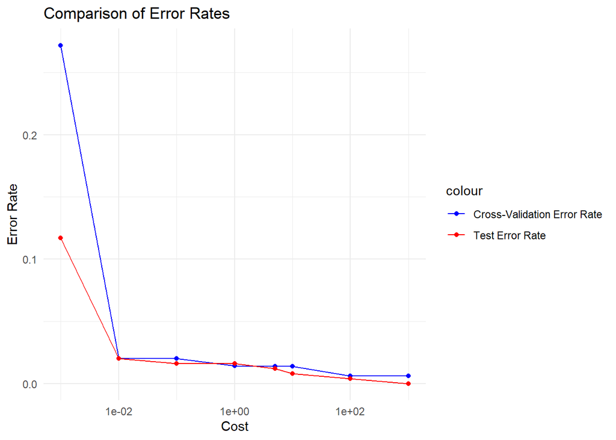

```r
ggplot(comparison_data, aes(x = cost)) +
  geom_line(aes(y = cv_error_rate, color = "Cross-Validation Error Rate")) +
  geom_point(aes(y = cv_error_rate, color = "Cross-Validation Error Rate")) +
  geom_line(aes(y = test_error_rate, color = "Test Error Rate")) +
  geom_point(aes(y = test_error_rate, color = "Test Error Rate")) +
  scale_x_log10() +
  labs(title = "Comparison of Error Rates", x = "Cost", y = "Error Rate") +
  theme_minimal() +
  scale_color_manual(values = c("Cross-Validation Error Rate" = "blue", "Test Error Rate" = "red"))
```

This figure is a visual representation of the values in the table above. The graph clearly shows that as the cost increases, both the cross-validation and test error rates decrease, stabilizing at higher cost values. The biggest difference between the two lines can be seen at the first point where the cost is lowest, the test error there is way lower than the CV error rate. Moving on the error rates stabilize at similar levels in both cases.

# Part d

*Discuss your results.*

The results I get in this exercise show that while increasing the cost parameter in an SVM model does lead to a reduction in both training and test error rates, there is a point beyond which the benefits diminish. Specifically, we observed that a cost value of 1000 results in the lowest test error rate of 0%, aligning closely with the minimal cross-validation error rates. This supports the claim that a support vector classifier with a high cost can effectively minimize errors. However, the improvements become marginal beyond certain cost values and high costs may lead to overfitting without substantial performance gains. Therefore, a balanced approach (in my case it might be optimal to set cost = 0.01), is likely the best to avoid unnecessary complexity and potential overfitting.

# Exercise 10.7

*Fit a neural network to the Default data. Use a single hidden layer with 10 units, and dropout regularization. Have a look at Labs 10.9.1– 10.9.2 for guidance. Compare the classifcation performance of your model with that of linear logistic regression.*

```r
set.seed(19800222)
```

Load the data

```r
library(ISLR)
data(Default)
```

Convert the default column to a binary factor

```r
Default$default <- ifelse(Default$default == "Yes", 1, 0)
```

Split the data into training and testing sets

```r
library(caret)
trainIndex <- createDataPartition(Default$default, p = 0.7, list = FALSE)
trainData <- Default[trainIndex,]
testData <- Default[-trainIndex,]
```

Fit a neural network with a single hidden layer of 10 units

```r
library(neuralnet)
nn_model <- neuralnet(default ~ balance + income, data = trainData, hidden = 10, linear.output = FALSE)
```

Make predictions on the test set

```r
nn_predictions <- compute(nn_model, testData[, c("balance", "income")])
nn_pred_class <- ifelse(nn_predictions$net.result > 0.5, 1, 0)
```

Calculate the accuracy of the neural network

```r
nn_confusion <- confusionMatrix(factor(nn_pred_class), factor(testData$default))
nn_accuracy <- nn_confusion$overall["Accuracy"]
print(paste("Neural Network Accuracy: ", nn_accuracy))
```

```
## [1] "Neural Network Accuracy:  0.97"
```

Fit a logistic regression model

```r
log_model <- glm(default ~ balance + income, data = trainData, family = binomial)
```

Make predictions on the test set using logistic regression

```r
log_predictions <- predict(log_model, newdata = testData, type = "response")
log_pred_class <- ifelse(log_predictions > 0.5, 1, 0)
```

Calculate the accuracy of the logistic regression model

```r
log_confusion <- confusionMatrix(factor(log_pred_class), factor(testData$default))
log_accuracy <- log_confusion$overall["Accuracy"]
print(paste("Logistic Regression Accuracy: ", log_accuracy))
```

```
## [1] "Logistic Regression Accuracy:  0.977"
```

**Comparison of Classification Performance:**

*Note: I tried to run my code with several different seeds, the results were rather similar with logistic regression model having a slightly higher accuracy than the neural network model by ~0.5-2%.*